# Climate change vulnerability assessment with ccva

A climate change vulnerability assessment (CCVA) asks which species are most at risk from climate change. Almost every CCVA rests on the same framework:

$$\text{Vulnerability} =
f(\text{Exposure}, \text{Sensitivity}, \text{Adaptive
capacity}).$$

In practice $f$ is usually a sum of expert-scored traits with arbitrary weights, never tested for internal consistency, never validated against an observable outcome, and reported without uncertainty. **ccva** keeps the framework but puts it on a statistical footing:

1. **Data** – any dataset; each column is tagged to a component.
2. **Components** – each computed from its own predictors by a chosen method.
3. **Vulnerability** – from the conventional weighted index (Ofori et al.
   2017. to a latent-variable model in which vulnerability is *inferred* from observable proxies.
4. **Constraints** – ecological knowledge imposed explicitly on predictors and on each component’s role.

Every step has a plot. All data in this vignette are simulated and have no biological meaning.

```r
library(ccva)
```

## 1. Data

`ccva_sim` holds 300 simulated species generated from a known latent structure: correlated latent exposure, sensitivity and adaptive capacity drive a latent vulnerability $V^*$. Each component is observed only through its indicators, and vulnerability only through three proxies – an IUCN-like status, a population trend and range change. Because the truth is known, we can check which method recovers it.

`as_ccva()` is the data contract. It tags each column to a component and records its **direction**: whether a higher value means *more* of the component (or, for an outcome, *more* vulnerable). A declining population trend and a range loss are bad news, so both get direction `-1`:

```r
d <- as_ccva(ccva_sim,
  exposure    = c("E1_risk", "E2_risk", "E3_risk"),
  sensitivity = grep("^s[0-9]+_", names(ccva_sim), value = TRUE),
  adaptive    = grep("^a[0-9]+_", names(ccva_sim), value = TRUE),
  outcomes    = c("iucn", "pop_trend", "range_change"),
  direction   = c(pop_trend = -1, range_change = -1),
  id = "species")
d$truth <- ccva_sim[c("E_star", "S_star", "A_star", "V_star")]
d
```

```
#> <ccva_data> 300 units
#>   Exposure            3 indicators: E1_risk, E2_risk, E3_risk
#>   Sensitivity        11 indicators: s1_thermal, s2_range, s3_climzones, s4_habitat, ... +7
#>   Adaptive capacity   4 indicators: a1_genetic, a2_bodysize, a3_lowfrag, a4_microhab
#>   Outcomes            3 proxys:     iucn, pop_trend (-), range_change (-)
#>   (-) marks indicators where a higher value means less of the component.
```

(`ccva_sim_data()` does exactly this in one call.) With real data, the exposure indicators usually come from a species distribution model. `ccva_sdm_exposure()` turns the cell counts of thresholded current and future habitat maps into Ofori’s three exposure indices, already recoded so that higher means more exposed:

```r
ccva_sdm_exposure(n_current = c(120, 80), n_future = c(60, 95),
                  n_overlap = c(50, 70), n_protected = c(30, 10))
```

```
#>   E1_change E2_overlap E3_protected E1_risk   E2_risk E3_risk
#> 1   -0.5000  0.4166667        0.250  0.5000 0.5833333   0.750
#> 2    0.1875  0.8750000        0.125 -0.1875 0.1250000   0.875
```

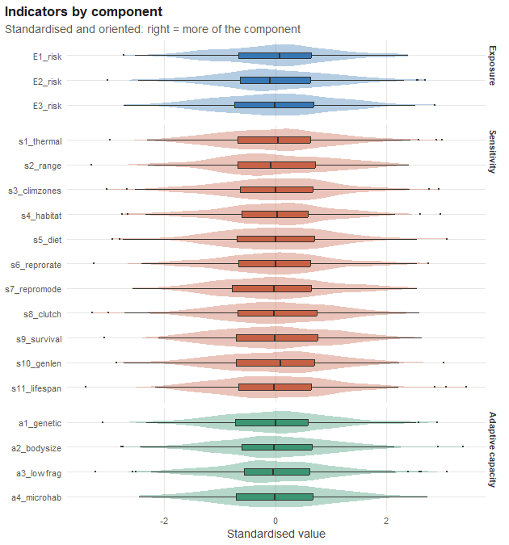

```r
ccva_plot(d, "indicators")
```

### Before combining anything: diagnostics

Summing indicators assumes they measure one construct; adding components assumes they are not redundant. `ccva_check()` tests both.

```r
chk <- ccva_check(d)
chk
```

```
#> <ccva_check> internal consistency (Cronbach's alpha)
#>   exposure       3 indicators  alpha 0.868  (std 0.868)  mean r 0.69  good
#>   sensitivity   11 indicators  alpha 0.871  (std 0.871)  mean r 0.38  good
#>   adaptive       4 indicators  alpha 0.801  (std 0.802)  mean r 0.50  good
#>   guide (reflective components): >= 0.8 good, >= 0.7 acceptable, < 0.6 questionable;
#>   alpha rises with the number of indicators, so compare mean r too
#>
#> cross-component Spearman correlations
#>             exposure sensitivity adaptive
#> exposure       1.000       0.269   -0.157
#> sensitivity    0.269       1.000   -0.172
#> adaptive      -0.157      -0.172    1.000
#>
#> no indicator pairs with |r| > 0.90
```

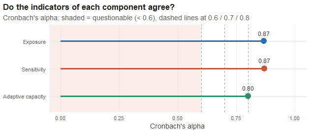

```r
ccva_plot(chk, "alpha")
```

## 2. The conventional baseline: Ofori et al. (2017)

Ofori and colleagues scored every indicator 1–3, summed the scores within each component, and combined the components. `component_method = "ordinal"` reproduces the scoring; the weighted method uses the corrected normalisation $V = (E + S - A + 1)/3$, which maps the full range of $E + S - A$ onto $[0, 1]$ without clipping.

```r
ofori <- ccva_combine(d, "weighted", component_method = "ordinal")
ofori
```

```
#> <ccva_fit> weighted index | 300 units | constraints: 4 rule(s)
#>   components: exposure (ordinal), sensitivity (ordinal), adaptive (ordinal)
#>   classes:    Low 19 | Moderate 217 | High 64
```

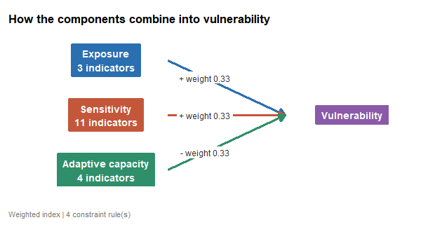

```r
ccva_plot(ofori, "structure")
```

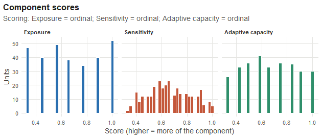

```r
ccva_plot(ofori, "components")
```

The weighted index makes it easy to see what drives each species’ score:

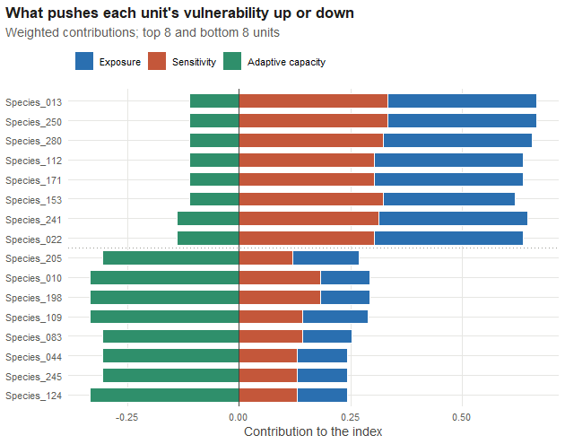

```r
ccva_plot(ofori, "contributions", n = 8)
```

## 3. Vulnerability as a latent variable

Vulnerability is never observed directly; we observe its consequences. The latent model treats it that way: $V^*$ is measured by the three outcome proxies and caused by latent exposure, sensitivity and adaptive capacity, each measured by its own indicators.

The three exposure indices share a denominator (current habitat area), so their errors are correlated. We declare that in `shared_error`; it is modelled by an orthogonal method factor.

```r
latent <- ccva_combine(d, "latent",
  shared_error = list(c("E1_risk", "E2_risk", "E3_risk")))
latent
```

```
#> <ccva_fit> latent SEM | 300 units | constraints: 4 rule(s)
#>   components: exposure (mean), sensitivity (mean), adaptive (mean)
#>   classes:    Low 39 | Moderate 200 | High 61
#>   fit: CFI 1.000, TLI 1.000, RMSEA 0.004, SRMR 0.037
#>   effects on V*: exposure +0.66, sensitivity +0.41, adaptive -0.25 (standardised)
```

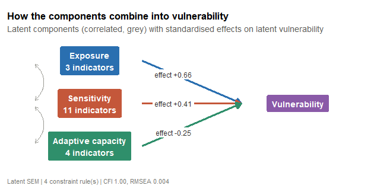

```r
ccva_plot(latent, "structure")
```

The measurement model shows how strongly each indicator reflects its component – a data-driven replacement for expert weights:

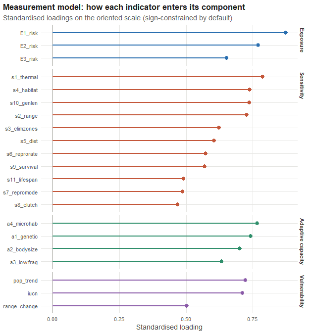

```r
ccva_plot(latent, "effects")
```

### Which method recovers the truth?

```r
cmp <- ccva_compare(ofori = ofori, latent = latent)
cmp
```

```
#> <ccva_comparison> Spearman correlation of scores with each target
#>  method  iucn pop_trend range_change V* (truth) class_agreement
#>   ofori 0.580     0.584        0.451      0.812            1.00
#>  latent 0.745     0.748        0.481      0.888            0.85
#>
#> rank correlation between methods
#>        ofori latent
#> ofori  1.000  0.897
#> latent 0.897  1.000
```

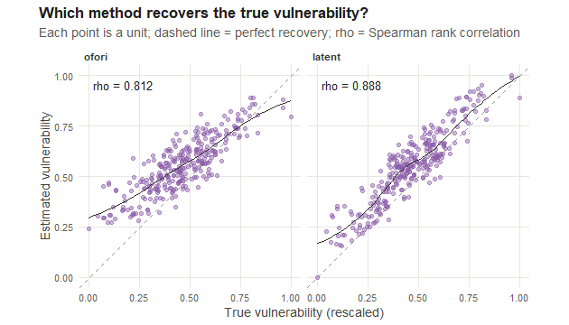

```r
ccva_plot(cmp, "truth")
```

The latent model recovers the true vulnerability better than the Ofori index, because it uses the outcome proxies to infer $V^*$ instead of computing it from discretised scores. Rankings change between methods:

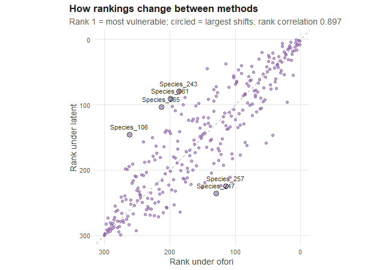

```r
ccva_plot(cmp, "ranks")
```

## 4. Constraints: imposing ecological knowledge

Free estimation ignores what ecologists already know. In ccva that knowledge is imposed explicitly, at two levels:

- **predictor level** – the sign of each indicator’s loading, bounds, equality between indicators, or a fixed value (0 drops it);
- **component level** – exposure and sensitivity raise vulnerability, adaptive capacity lowers it; bounds on the effects; or adaptive capacity acting only as a moderator.

The default constraints encode the standard ecological directions:

```r
ccva_default_constraints()
```

```
#> <ccva_constraints> 4 rule(s)
#>   [component] exposure: positive effect
#>   [component] sensitivity: positive effect
#>   [component] adaptive: negative effect
#>   [predictor] all indicators & outcomes: sign follows declared direction
```

Rules are added on top of the defaults:

```r
cons <- ccva_constraints(
  constrain_equal(c("a1_genetic", "a2_bodysize")),
  constrain_fixed("s7_repromode", 0),
  constrain_bounds("exposure", lower = 0, upper = 2))
cons
```

```
#> <ccva_constraints> 7 rule(s)
#>   [component] exposure: positive effect
#>   [component] sensitivity: positive effect
#>   [component] adaptive: negative effect
#>   [predictor] all indicators & outcomes: sign follows declared direction
#>   [predictor] equal: a1_genetic = a2_bodysize
#>   [predictor] s7_repromode fixed at 0 (dropped)
#>   [component] exposure in [0, 2]
```

```r
fit_c <- ccva_combine(d, "latent", constraints = cons,
  shared_error = list(c("E1_risk", "E2_risk", "E3_risk")))
fit_c$details$effects
```

```
#>     component   estimate        se        std       pvalue
#> 1    exposure  2.0000000 0.0000000  0.6265393           NA
#> 2 sensitivity  1.3047784 0.2307204  0.4087475 1.556320e-08
#> 3    adaptive -0.7932589 0.1926316 -0.2485039 3.821578e-05
```

### When do constraints matter?

With 300 species the free estimates already have the ecological signs, so constraints change little. CCVAs, however, are usually run on a few dozen species. Here we fit the latent model with and without constraints to 20 simulated datasets of 50 species each:

```r
small_n <- do.call(rbind, lapply(1:20, function(i) {
  s <- ccva_simulate(n = 50, seed = 100 + i)
  run <- function(cons) {
    f <- tryCatch(suppressWarnings(ccva_combine(s, "latent",
           constraints = cons,
           shared_error = list(c("E1_risk", "E2_risk", "E3_risk")))),
           error = function(e) NULL)
    if (is.null(f)) return(c(converged = 0, rho = NA))
    c(converged = f$details$converged,
      rho = cor(f$score, s$truth$V_star, method = "spearman"))
  }
  rbind(data.frame(model = "constrained", t(run(NULL))),
        data.frame(model = "free", t(run(ccva_unconstrained()))))
}))
aggregate(cbind(converged, rho) ~ model, small_n, mean, na.action = na.pass)
```

```
#>         model converged       rho
#> 1 constrained      0.95 0.9118463
#> 2        free      0.95 0.9118559
```

### Adaptive capacity as a moderator

Biologically, adaptive capacity does nothing on its own: it modulates the impact of exposure and sensitivity. `constrain_moderator()` removes its main effect. In the shape-constrained model this fits monotone interaction surfaces $f_{EA}(E, A) + f_{SA}(S, A)$; in the weighted index it gives $V \propto E(1 - \gamma_E A) + S(1 - \gamma_S A)$.

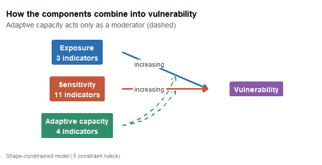

```r
mod <- ccva_combine(d, "shape",
                    constraints = ccva_constraints(constrain_moderator()))
ccva_plot(mod, "structure")
```

Without the moderator constraint, the shape-constrained model learns the *shape* of each component’s effect from data while the *direction* is fixed:

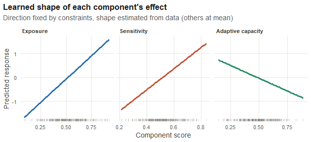

```r
shape <- ccva_combine(d, "shape")
ccva_plot(shape, "effects")
```

## 5. High-dimensional predictors

Some components arrive with more predictors than species – genomic markers for adaptive capacity are the obvious case. The penalised two-stage method estimates latent vulnerability from the outcomes, then regresses it on every predictor with a LASSO whose coefficient signs follow the constraints.

```r
g <- ccva_simulate(n = 150, n_genomic = 300, n_causal = 10, seed = 3)
length(unlist(g$indicators))   # predictors
```

```
#> [1] 318
```

```r
pen <- ccva_combine(g, "penalised")
pen
```

```
#> <ccva_fit> penalised two-stage | 150 units | constraints: 4 rule(s)
#>   components: exposure (mean), sensitivity (mean), adaptive (mean)
#>   classes:    Low 19 | Moderate 90 | High 41
#>   selected predictors: 23 of 318
```

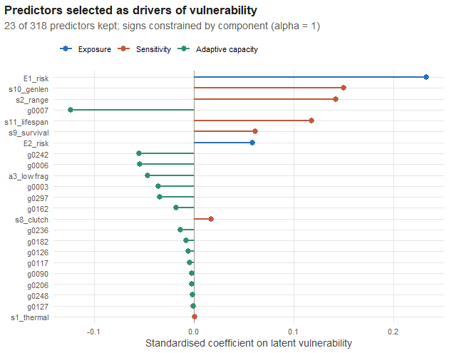

```r
ccva_plot(pen, "effects")
```

## 6. How certain is the ranking?

A sorted list of point estimates implies a precision the data rarely support. `ccva_uncertainty()` refits the whole pipeline on bootstrap resamples; for the latent model each species’ factor-score error is added as well.

```r
unc <- ccva_uncertainty(latent, "bootstrap", R = 40, seed = 1,
                        progress = FALSE)
unc
```

```
#> <ccva_uncertainty> bootstrap (sampling), 40 replicates, 95% intervals
#>   mean interval width: 0.302 (score range 1.000)
#>   pairs with overlapping intervals: 71.1%
#>   robust pairwise rankings (P > 0.95): 51.8%
#>   most vulnerable:
#>     Species_241      1.000 [0.884, 1.209]  rank 1 (1-22)
#>     Species_280      0.989 [0.865, 1.144]  rank 2 (1-16)
#>     Species_013      0.953 [0.839, 1.151]  rank 3 (1-19)
#>     Species_287      0.935 [0.776, 1.047]  rank 4 (1-22)
#>     Species_022      0.921 [0.796, 1.043]  rank 5 (1-27)
```

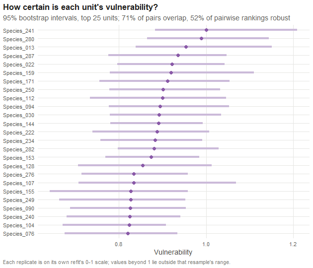

```r
ccva_plot(unc, "intervals", n = 25)
```

For the weighted index, a second question is how much the ranking depends on the arbitrary choice of weights:

```r
ccva_uncertainty(ofori, "weights", R = 1000, seed = 1)
```

```
#> <ccva_uncertainty> random weights (weighting), 1000 replicates, 95% intervals
#>   mean interval width: 0.365 (score range 0.646)
#>   pairs with overlapping intervals: 87.1%
#>   robust pairwise rankings (P > 0.95): 48.1%
#>   most vulnerable:
#>     Species_013      0.889 [0.712, 0.996]  rank 1 (1-1)
#>     Species_250      0.889 [0.712, 0.996]  rank 1 (1-1)
#>     Species_280      0.879 [0.710, 0.985]  rank 3 (3-3)
#>     Species_112      0.859 [0.704, 0.973]  rank 4 (4-12)
#>     Species_171      0.859 [0.704, 0.973]  rank 4 (4-12)
```

## 7. Classification and outputs

Cut-offs at 1/3 and 2/3 assume uniformly distributed scores. Alternatives calibrate them to an observed outcome or to natural clusters:

```r
sapply(c("uniform", "quantile", "mixture", "roc"), function(m)
  table(ccva_classify(latent$score, m, data = d)))
```

```
#>          uniform quantile mixture roc
#> Low           39      100      65  99
#> Moderate     200      100     199  58
#> High          61      100      36 143
```

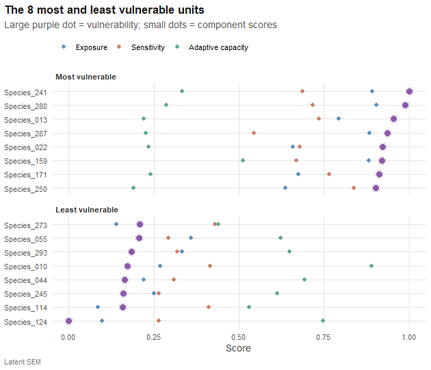

```r
ccva_plot(latent, "ranking", n = 8)
```

```r
head(ccva_rank(latent, unc))
```

```
#>            unit     score rank class  exposure sensitivity  adaptive     lower
#> 241 Species_241 1.0000000    1  High 0.8919842   0.6868433 0.3320612 0.8835635
#> 280 Species_280 0.9890865    2  High 0.9038663   0.7170390 0.2866167 0.8646315
#> 13  Species_013 0.9532944    3  High 0.7927621   0.7350135 0.2202469 0.8391743
#> 287 Species_287 0.9351071    4  High 0.8846028   0.5437302 0.2262880 0.7762848
#> 22  Species_022 0.9214363    5  High 0.6583220   0.6789288 0.2349839 0.7960000
#> 159 Species_159 0.9196621    6  High 0.8824058   0.6684904 0.5109389 0.7789079
#>        upper rank_low rank_high
#> 241 1.208669    1.000    22.250
#> 280 1.143911    1.000    16.000
#> 13  1.150911    1.000    19.025
#> 287 1.046994    1.000    22.400
#> 22  1.042746    1.000    27.025
#> 159 1.110225    1.975    27.075
```

`ccva_report(latent, "report.html", uncertainty = unc, comparison = cmp)` writes all of this into one reproducible HTML report.

## 8. Extending the framework

New component or combination methods register with `ccva_register()` and are then used exactly like built-in ones:

```r
ccva_register("median", function(X, anchor, signs, ...) {
  z <- scale(X)
  ctr <- attr(z, "scaled:center"); scl <- attr(z, "scaled:scale")
  list(score = apply(z, 1, median),
       predict = function(M) apply(scale(M, ctr, scl), 1, median))
}, type = "component", description = "Median of standardised indicators")

ccva_sensitivity(d, method = "median")
```

```
#> <ccva_component> Sensitivity via 'median' from 11 indicator(s)
#>   score: mean -0.008, range [-1.894, 1.994]
```

```r
ccva_unregister("median")
```

## References

Ofori, B. Y., Stow, A. J., Baumgartner, J. B. and Beaumont, L. J. (2017). Influence of adaptive capacity on the outcome of climate change vulnerability assessment. *Scientific Reports* 7, 12979.

Bollen, K. A. (1989). *Structural Equations with Latent Variables*. Wiley.

Pya, N. and Wood, S. N. (2015). Shape constrained additive models. *Statistics and Computing* 25, 543–559.

Rosseel, Y. (2012). lavaan: an R package for structural equation modeling. *Journal of Statistical Software* 48(2), 1–36.